# Diversité autour des Arbres du POSL

Florence Puech

Eric Marcon

20 mars 2022

Abstract

Diversité à distance.

# 1 Données

```r
load("data/POSL.RData")
```

# 2 Jeux de points

## 2.1 Tous les arbres de 2021

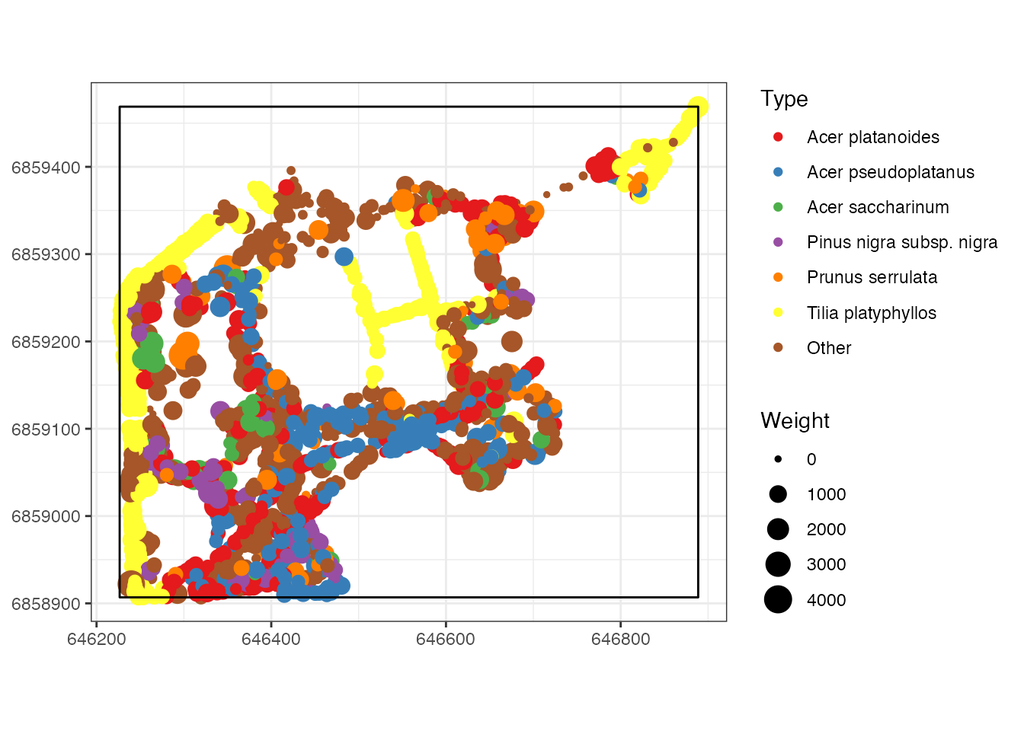

```r
library("dbmss")
BDD_Vivants_et_Abattus_renseignes_POSL %>%
    # Le poids est la surface terrière
mutate(PointWeight = Circonference^2/4/pi) %>%
    rename(PointType = GenrEsp) %>%
    as.wmppp(unitname = c("meter", "meters")) ->
    POSL_VA_wmppp
autoplot(POSL_VA_wmppp)
```

# 3 Diversité

## 3.1 A distance

Accumulation de la diversité de 0 à 500 m pour q=0, 1 et 2 (Richesse, Shannon, Simpson) avec hypothèse nulle de localisation aléatoire.

```r
library("SpatDiv")
# Calcul avec H0 touts les 50 m pour ne pas avoir
# de NA (limite de SpatDiv à corriger)
Accum <- DivAccum(POSL_VA_wmppp, r.seq = c(0, seq(from = 25,
    to = 50, by = 5), seq(from = 100, to = 500, by = 50)),
    q.seq = 0:2, H0 = "RandomLocation", NumberOfSimulations = 100,
    Individual = TRUE)
# Calcul à 10m et 25m, sans HO
Accum10 <- DivAccum(POSL_VA_wmppp, r.seq = c(0, 10),
    q.seq = 0:2, Individual = TRUE)
Accum25 <- DivAccum(POSL_VA_wmppp, r.seq = c(0, 25),
    q.seq = 0:2, Individual = TRUE)
```

### 3.1.1 Richesse : q=0

Courbe d’accumulation

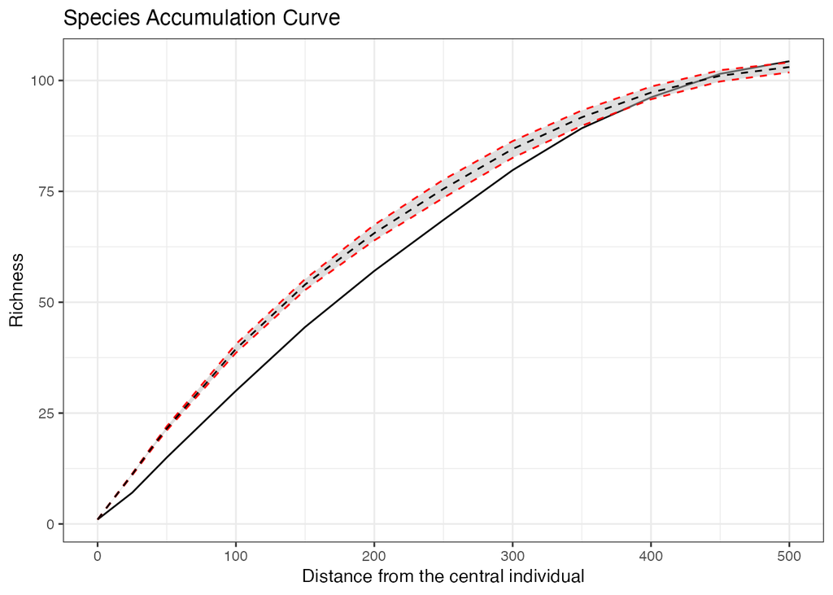

```r
autoplot(Accum, q = 0)
```

La valeur asymptotique est celle du parc entier

```r
Richness(POSL_VA_wmppp, Correction = "None")
```

```
## None
##  109
```

Carte de la richesse à 10 m:

```r
MapPlot(Accum10, Order = 0, NeighborHood = 10, Points = TRUE)
```

```
## [using ordinary kriging]
```

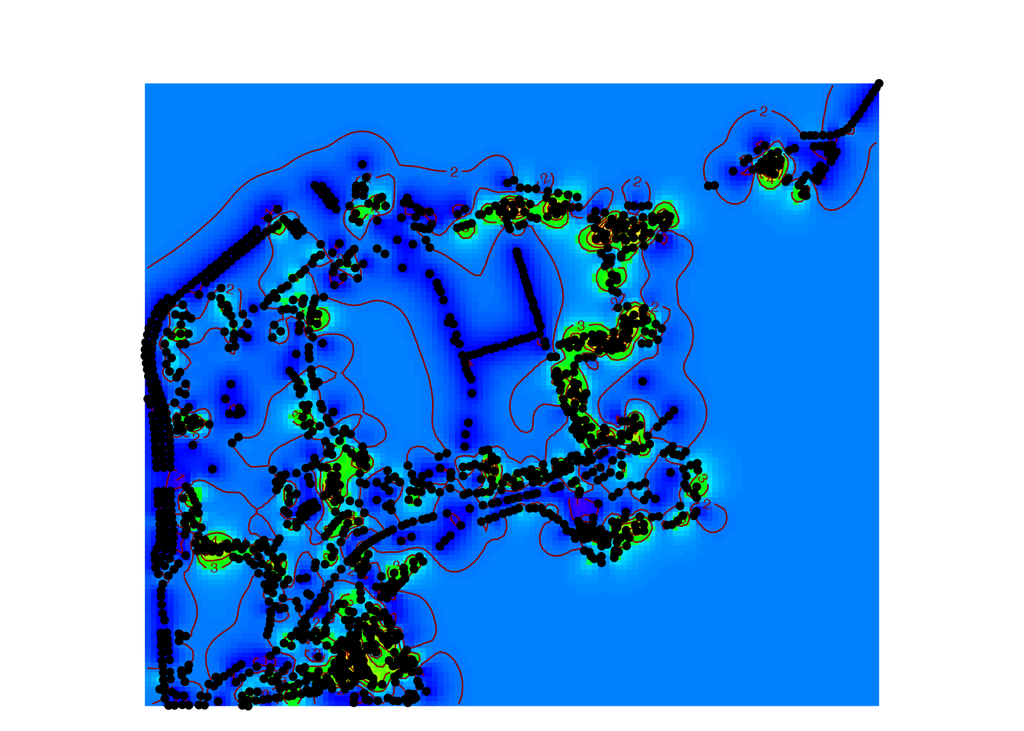

```r
# Arbres abattus
BDD_Vivants_et_Abattus_renseignes_POSL %>%
    filter(Etat == "Abattu") -> Abattus
with(Abattus, points(x = X, y = Y, pch = 20))
```

Carte de la richesse à 25 m:

```r
MapPlot(Accum25, Order = 0, NeighborHood = 25, Points = TRUE)
```

```
## [using ordinary kriging]
```

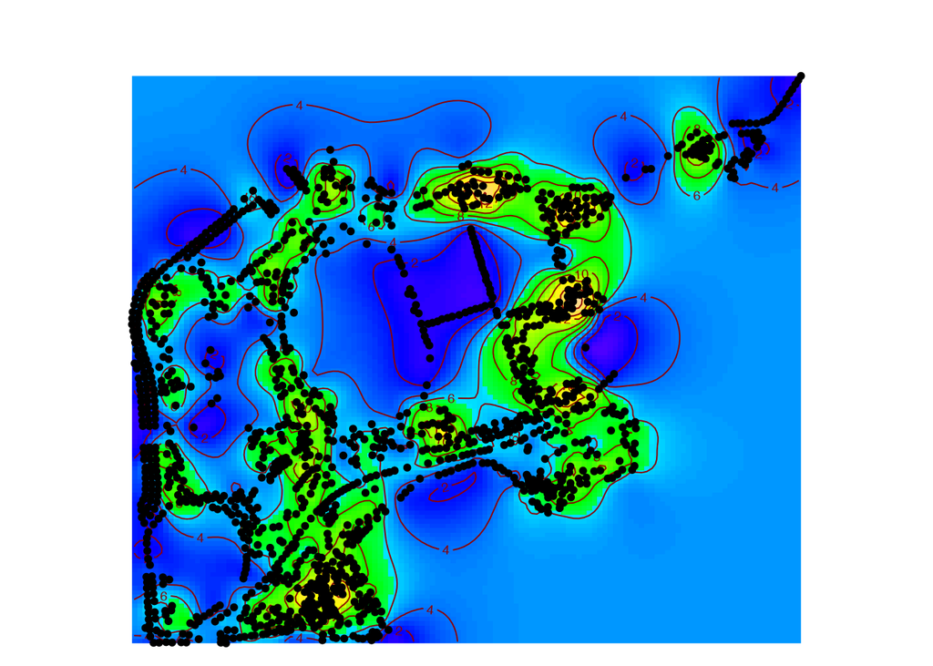

```r
# Arbres abattus
BDD_Vivants_et_Abattus_renseignes_POSL %>%
    filter(Etat == "Abattu") -> Abattus
with(Abattus, points(x = X, y = Y, pch = 20))
```

### 3.1.2 Shannon : q=1

Courbe d’accumulation

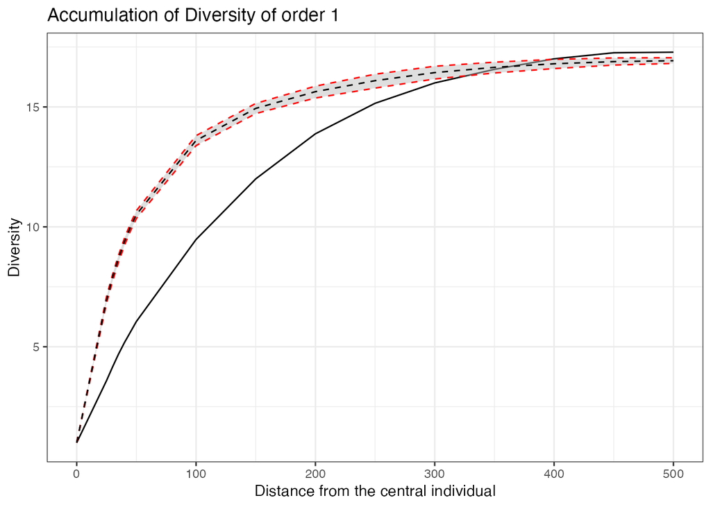

```r
autoplot(Accum, q = 1)
```

```r
Diversity(POSL_VA_wmppp, q = 1, Correction = "None")
```

[output not shown]

Carte de la diversité d’ordre 1 à 25 m:

```r
MapPlot(Accum25, Order = 1, NeighborHood = 25)
```

```
## [using ordinary kriging]
```

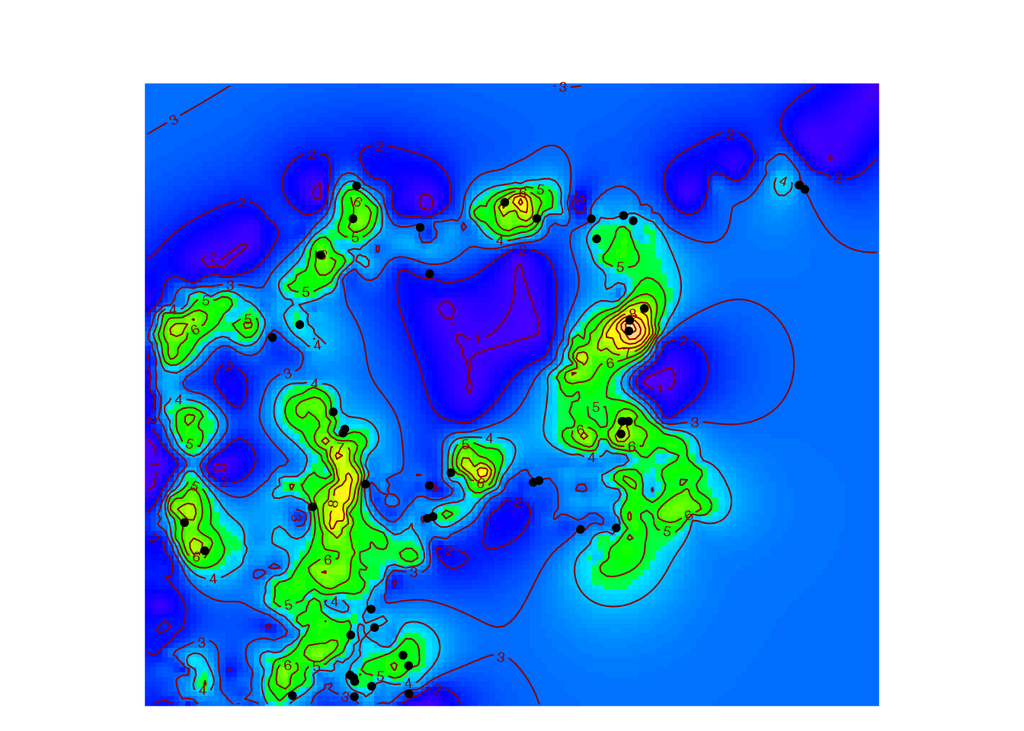

```r
# Arbres abattus
BDD_Vivants_et_Abattus_renseignes_POSL %>%
    filter(Etat == "Abattu") -> Abattus
with(Abattus, points(x = X, y = Y, pch = 20))
```

### 3.1.3 Simpson : q=2

Courbe d’accumulation

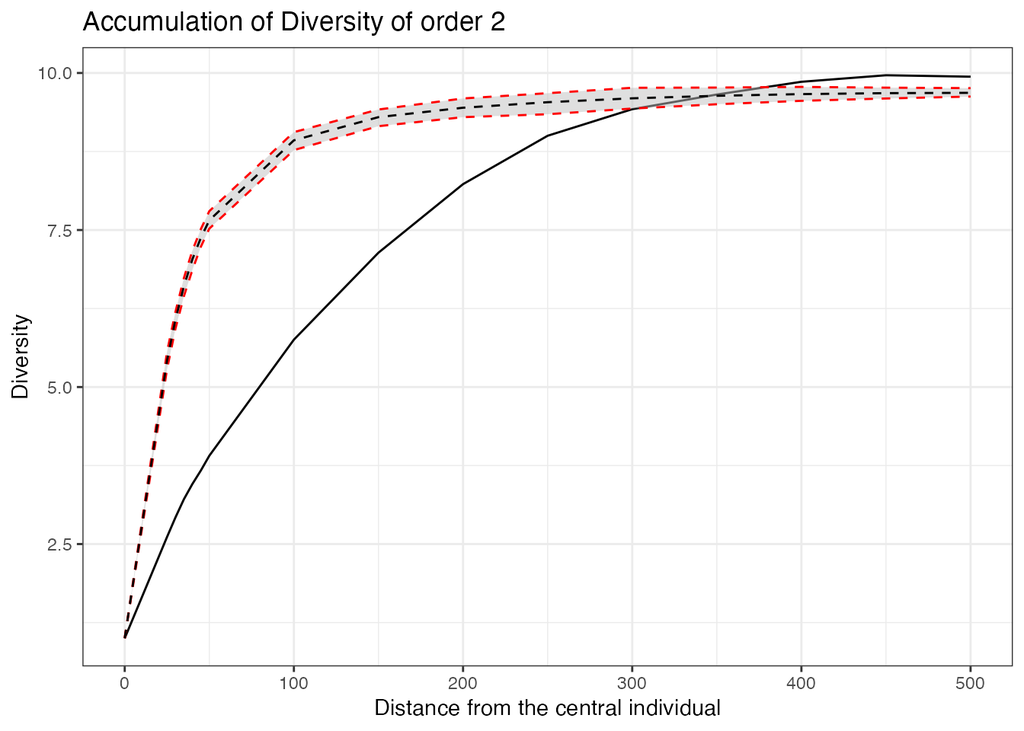

```r
autoplot(Accum, q = 2)
```

La valeur asymptotique est celle du parc entier

```r
Diversity(POSL_VA_wmppp, q = 2, Correction = "None")
```

```
##     None
## 10.15975
```

Carte de la diversité d’ordre 2 à 25 m:

```r
MapPlot(Accum25, Order = 2, NeighborHood = 25)
```

```
## [using ordinary kriging]
```

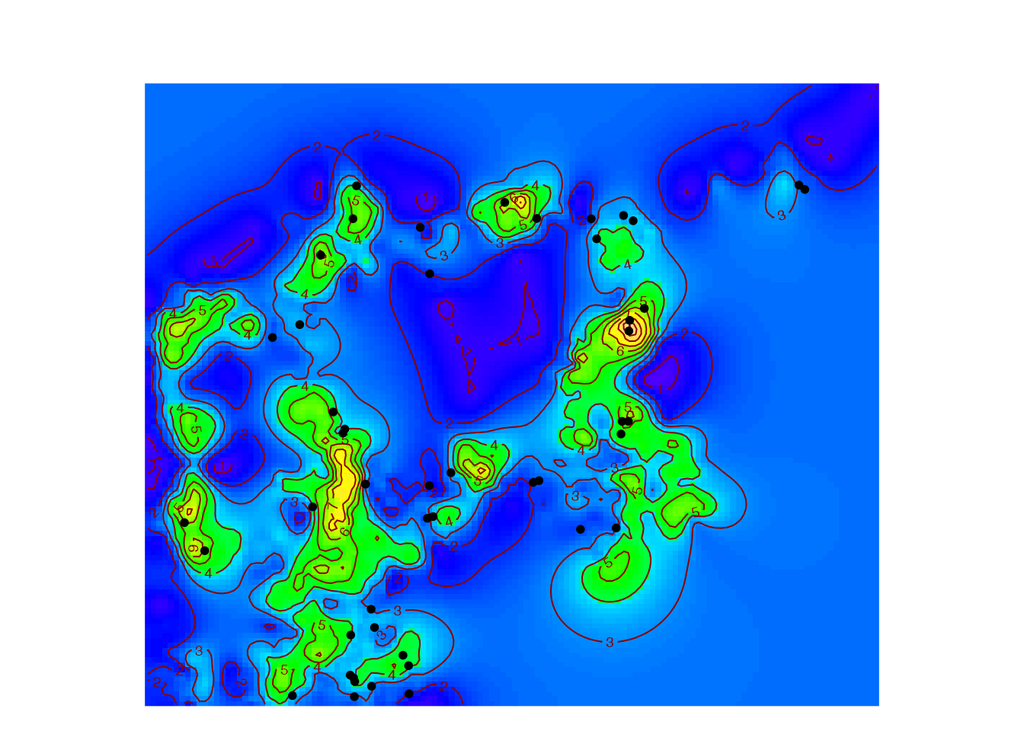

```r
# Arbres abattus
BDD_Vivants_et_Abattus_renseignes_POSL %>%
    filter(Etat == "Abattu") -> Abattus
with(Abattus, points(x = X, y = Y, pch = 20))
```

# 4 Comparaison de la diversité

Diversité d’ordres 0, 1 et 2 à 25m autour des arbres:

```r
Distance <- 2  # 25 m
Accum25$Neighborhoods[, Distance, ] %>%
    t %>%
    as_tibble %>%
    # Les lignes sont les arbres, les colonnes
    # l'ordre de la diversité
print -> DivLocale
```

```
## # A tibble: 1,450 × 3
##      `0`   `1`   `2`
##    <dbl> <dbl> <dbl>
##  1     2  1.75  1.59
##  2     4  2.04  1.63
##  3    10  5.18  4.43
##  4     7  2.21  1.69
##  5     2  2.00  2.00
##  6     5  3.32  2.77
##  7    11  6.23  4.24
##  8     1  1     1
##  9     5  4.39  4.05
## 10     6  3.88  3.36
## # … with 1,440 more rows
```

A faire : écrire dans SpatDiv une fonction qui extraie les valeurs de diversité locale (arguments : q et r) pour remplacer ce code.

Intégration de la diversité locale au jeu de données:

```r
BDD_Vivants_et_Abattus_renseignes_POSL %>%
    bind_cols(DivLocale) %>%
    filter(EspeceFrancais == "Erable") -> BDD_Erables_Div
```

Diversité locale autour des arbres abattus.

## 4.1 Richesse

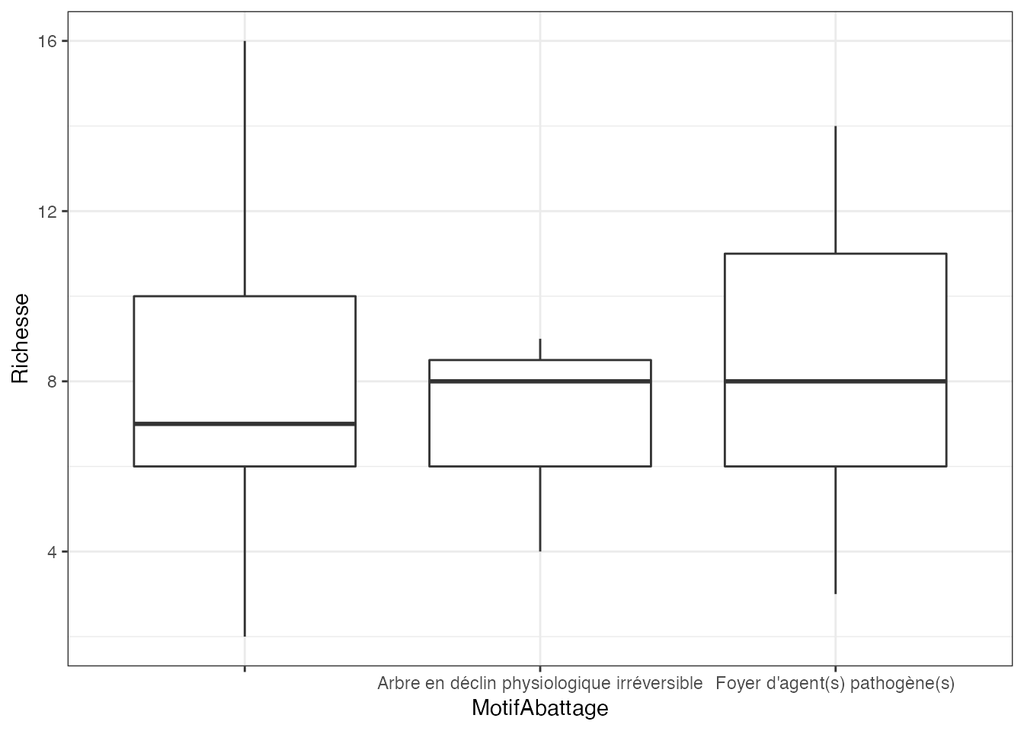

```r
BDD_Erables_Div %>%
    ggplot() + geom_boxplot(aes(x = MotifAbattage,
    y = `0`)) + labs(y = "Richesse")
```

## 4.2 Shannon

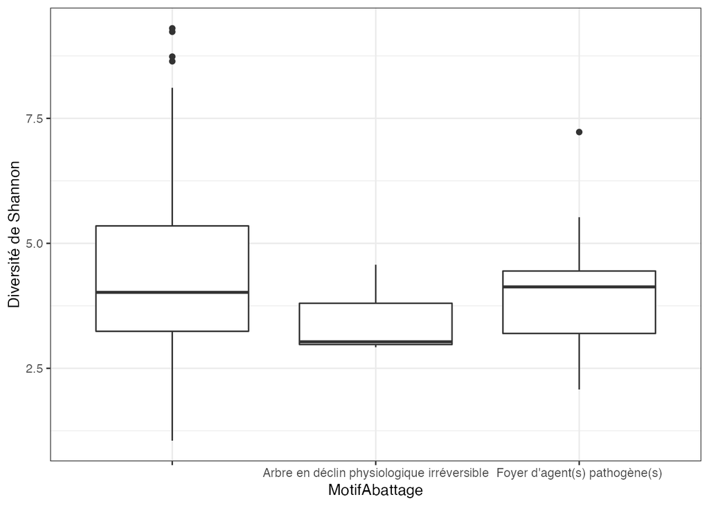

```r
BDD_Erables_Div %>%
    ggplot() + geom_boxplot(aes(x = MotifAbattage,
    y = `1`)) + labs(y = "Diversité de Shannon")
```

## 4.3 Simpson

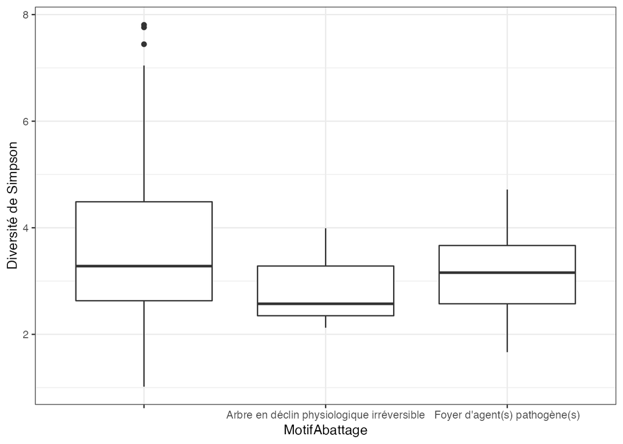

```r
BDD_Erables_Div %>%
    ggplot() + geom_boxplot(aes(x = MotifAbattage,
    y = `2`)) + labs(y = "Diversité de Simpson")
```

## 4.4 Conclusion

La diversité à 25m est la même pour les victimes de la maladie de la suie que pour tous les érables. Les érables en déclin ne sont que 3, donc pas de conclusion.